# Algortitma Linear Regression dengan R

# Algoritma

Pada tutorial kali ini, akan membahas mengenai Regression Model. Apa itu regression model?

Regression Model merupakan salah satu metode dalam machine learning yang dapat digunakan untuk melakukan prediksi dari suatu target variabel yang bersifat numerik. Keunggulan dari regression model adalah selain kita dapat memperoleh hasil akurasi dari prediksi kita, kita juga memperoleh model untuk prediksi data serta dapat melakukan interpretasi dari model yang kita miliki.

Regression Model memiliki beberapa tipe tergantung dari bentuk data yang kita miliki. Regression Model yang paling simple adalah Linear Regression. Linear Regression memiliki pembagian lagi, tergantung prediktor yang kita gunakan, hanya ada 1 prediktor atau lebih dari satu prediktor. Jika satu prediktor maka kita gunakan Simple Linear Regression, namun jika lebih dari satu prediktor maka kita gunakan Multiple Linear Regression.

# Tahapan

Linear Regression (regresi linier) mencoba untuk memodelkan hubungan antara dua variabel dengan memasang persamaan linier untuk mengamati data. Linear Regression berusaha menemukan hubungan matematis antar variabel. Berikut tahapan algoritma Linear Regression. 1. Siapkan data 2. Identifikasi Atribut dan Label 3. Hitung X2, Y2, XY dan total dari masing-masingnya. 4. Hitung a dan b berdasarkan persamaan yang sudah ditentukan 5. Buat Model Persamaan Regresi Linear Sederhana

# Eksperimen

Model dari Linear Regression adalah sebagai berikut :

y^=β0+β1x1

di mana :

y^ : nilai prediksi β0 : nilai intercept β1 : nilai koefisien regresi unutk x1 x1 : variabel prediktor Untuk memperjelas yang akan kita pelajari tentang linear regression, kita akan gunakan data red wines quality. Berdasarkan data red wines quality kita akan melakukan prediksi terhadap nilai quality pada red wines yang ada berdasarkan parameter-parameter atau variabel prediktor yang telah tersedia. Berikut ini isi dari data red wines quality.

```r
wine <- library(haven)
red_wines_quality <- read_sav("red wines quality.sav")
View(red_wines_quality)
str(red_wines_quality)
```

```
## tibble [1,600 × 12] (S3: tbl_df/tbl/data.frame)
##  $ Fixed_Acidity       : num [1:1600] 7.4 7.8 7.8 11.2 7.4 7.4 7.9 7.3 7.8 7.5 ...
##   ..- attr(*, "format.spss")= chr "F8.2"
##  $ Volatile_Acidity    : num [1:1600] 0.7 0.88 0.76 0.28 0.7 0.66 0.6 0.65 0.58 0.5 ...
##   ..- attr(*, "format.spss")= chr "F8.2"
##  $ Citric_Acid         : num [1:1600] 0 0 0.04 0.56 0 0 0.06 0 0.02 0.36 ...
##   ..- attr(*, "format.spss")= chr "F8.2"
##  $ Residual_Sugar      : num [1:1600] 1.9 2.6 2.3 1.9 1.9 1.8 1.6 1.2 2 6.1 ...
##   ..- attr(*, "format.spss")= chr "F8.2"
##  $ Chlorides           : num [1:1600] 0.076 0.098 0.092 0.075 0.076 0.075 0.069 0.065 0.073 0.071 ...
##   ..- attr(*, "format.spss")= chr "F8.2"
##  $ Free_Sulfur_Dioxide : num [1:1600] 11 25 15 17 11 13 15 15 9 17 ...
##   ..- attr(*, "format.spss")= chr "F8.2"
##  $ Total_Sulfur_Dioxide: num [1:1600] 34 67 54 60 34 40 59 21 18 102 ...
##   ..- attr(*, "format.spss")= chr "F8.2"
##  $ Density             : num [1:1600] 0.998 0.997 0.997 0.998 0.998 ...
##   ..- attr(*, "format.spss")= chr "F8.2"
##  $ Ph                  : num [1:1600] 3.51 3.2 3.26 3.16 3.51 3.51 3.3 3.39 3.36 3.35 ...
##   ..- attr(*, "format.spss")= chr "F8.2"
##  $ Sulphates           : num [1:1600] 0.56 0.68 0.65 0.58 0.56 0.56 0.46 0.47 0.57 0.8 ...
##   ..- attr(*, "format.spss")= chr "F8.2"
##  $ Alcohol             : num [1:1600] 9.4 9.8 9.8 9.8 9.4 9.4 9.4 10 9.5 10.5 ...
##   ..- attr(*, "format.spss")= chr "F8.2"
##  $ Quality             : num [1:1600] 5 5 5 6 5 5 5 7 7 5 ...
##   ..- attr(*, "format.spss")= chr "F8.2"
```

Data wine yang tela diimport berisi 12 variabel, dimana semua variabel bertipe numerik data. Untuk target variabel yang kita gunakan yaitu variabel quality karena disini kita ingin memprediksi besar kualitas dari red wine berdasarkan variabel prediktor yang ada.

## Build Model

Dalam melakukan prediksi menggunakan linear regression, kita gunakan function lm() yang ada pada R.

```r
model <- lm(Quality~., red_wines_quality)
summary(model)
```

```
##
## Call:
## lm(formula = Quality ~ ., data = red_wines_quality)
##
## Residuals:
##      Min       1Q   Median       3Q      Max
## -2.86880 -0.47704 -0.01624  0.45913  2.74600
##
## Coefficients:
##                        Estimate Std. Error t value Pr(>|t|)
## (Intercept)           6.0667298  0.6603736   9.187  < 2e-16 ***
## Fixed_Acidity        -0.0162772  0.0179901  -0.905  0.36572
## Volatile_Acidity     -1.1747188  0.1303364  -9.013  < 2e-16 ***
## Citric_Acid           0.3110261  0.1574682   1.975  0.04842 *
## Residual_Sugar        0.0338606  0.0135726   2.495  0.01270 *
## Chlorides            -3.5800132  0.4399462  -8.137 8.07e-16 ***
## Free_Sulfur_Dioxide   0.0071104  0.0023498   3.026  0.00252 **
## Total_Sulfur_Dioxide -0.0060509  0.0007684  -7.875 6.27e-15 ***
## Density              -0.0033268  0.0020815  -1.598  0.11018
## Ph                   -0.0464840  0.1685666  -0.276  0.78277
## Sulphates             1.1898450  0.1185110  10.040  < 2e-16 ***
## Alcohol               0.0011890  0.0005338   2.227  0.02605 *
## ---
## Signif. codes:  0 '***' 0.001 '**' 0.01 '*' 0.05 '.' 0.1 ' ' 1
##
## Residual standard error: 0.7022 on 1587 degrees of freedom
##   (1 observation deleted due to missingness)
## Multiple R-squared:  0.2491, Adjusted R-squared:  0.2438
## F-statistic: 47.85 on 11 and 1587 DF,  p-value: < 2.2e-16
```

Berdasarkan hasil analisis regresi yang kita lakukan diatas dengan menggunakan seluruh variabel prediktor, kita akan analisis satu persatu dari modelnya. Untuk melakukan analisis pada model regresi yang telah kita buat, kita perlu melihat apakah model yang kita buat mampu untuk mejelaskan target variabel yang kita miliki.

## Uji Overall

Uji yang pertama kita lakukan disebut uji overall. Untuk hipotesis yang digunakan yaitu :

H0 : Model tidak signifikan (Model belum mampu menjelaskan target variabel) H1 : Model signifikan (Model mampu menjelaskan target variabel)

Dalam melakukan uji overall, kita melihat nilai F-statistic yang ditampilkan dalam model dan melihat p-value yang paling bawah. Karena nilai p-value < α yaitu <2.2e-16 < 0.05 sehingga kita memperoleh keputusan tolak H0 yang artinya model yang kita buat dapat menjelaskan target variabel yang kita miliki yaitu quality.

## R Squared

Selanjutnya kita akan melihat kebaikan dari model yang telah kita buat. Untuk melihat kebaikan model kita, kita bisa menggunakan nilai Multiple R-Squared (untuk univariat regression) dan Adjusted R-Squared (untuk multiple regression). Nilai Multiple dan Adjusted R-Squared berkisar dari 0 hingga 1. Semakin mendekati 1, maka model yang kita miliki semakin bagus dalam artian variabel prediktor dapat menjelaskan target variabel kita dengan baik.

## Error

Karena nilai Multiple R-quared yang kita miliki kecil, kita bisa melihat dari nilai error dari hasil prediksi kita. Untuk melihat nilai error, ada beberapa perhitungan error yang bisa kita gunakan. Salah satunya yaitu RMSE (Root Mean Square Error)

```r
library(caret)
RMSE(model$fitted.values,red_wines_quality$Quality,na.rm = T)
```

```
## [1] 0.6995992
```

Nilai error yang kita dapatkan cukup kecil, sehingga kita bisa gunakan model regresi yang telah kita buat untuk memprediksi nilai quality selanjutnya.

## Uji Parsial

Selanjutnya untuk mengimprove dari model kita agar nilai R-Squared lebih tinggi, kita melakukan uji parsial. Uji parsial adalah untuk melihat apakah dari masing-masing variabel prediktor yang kita gunakan untuk melakukan prediksi berpengaruh signifikan terhadap target variabel yang kita miliki.

Hipotesis yang digunakan adalah sebagai berikut :

H0 : Variabel prediktor tidak signifikan (Variabel prediktor tidak berpengaruh terhadap nilai dari target variabel) H1 : variabel prediktor signifikan (Variabel prediktor berpengaruh terhadap nilai dari target variabel)

Untuk melakukan uji parsial atau melihat apakah berpengaruh atau tidak variabel prediktor yang kita gunakan bisa dilihat pada nilai Pr(>|t|). Jika nilai Pr(>|t|) lebih kecil dari nilai α = 0.05, maka dapat kita katakan bahwa variabel prediktor tersebut berpengaruh terhadap target variabel kita. Untuk simplenya, kita bisa liat tanda bintang-bintang disamping nilai Pr(>|t|), semakin banyak bintang disana, artinya variabel prediktor tersebut berpengaruh terhadap target variabel.

## Stepwise

Untuk mempermudah pengevaluasian variabel prediktor, kita dapat menggunakan metode stepwise. Stepwise merupakan metode yang digunakan untuk evaluasi variabel yang tidak berpengaruh terhadap model. Stepwise memiliki 3 cara dalam mengevaluasi variabel, diantaranya yaitu :

backward : Mengevaluasi model dengan cara memasukkan seluruh variabel prediktor lalu mengurangi satu persatu variabel prediktor yang tidak berpengaruh hingga memperoleh nilai AIC (Akaike Information Criterion) terkecil/R-Squared terbesar. forward : Mengevaluasi model dengan cara memasukkan satu persatu variabel yang dirasa berpengaruh terhadap target variabel hingga memperoleh nilai AIC terkecil/R-Squared terbesar. both : Mengevaluasi model dengan cara menambahkan dan mengurangi variabel-variabel yang dirasa berpengaruh dan tidak berpengaruh terhadap target variabel. Untuk melakukan analisis stepwise, kita membuat model sebagai berikut.

```r
model_none <- lm(Quality~1, red_wines_quality)
model_all <- lm(Quality~., red_wines_quality)
```

Untuk melakukan stepwise dengan cara backward, kita dapat menggunakan model_all.

```r
step(model_all,  direction = "backward")
```

```
## Start:  AIC=-1118.48
## Quality ~ Fixed_Acidity + Volatile_Acidity + Citric_Acid + Residual_Sugar +
##     Chlorides + Free_Sulfur_Dioxide + Total_Sulfur_Dioxide +
##     Density + Ph + Sulphates + Alcohol
##
##                        Df Sum of Sq    RSS     AIC
## - Ph                    1     0.038 782.65 -1120.4
## - Fixed_Acidity         1     0.404 783.02 -1119.7
## <none>                              782.61 -1118.5
## - Density               1     1.260 783.87 -1117.9
## - Citric_Acid           1     1.924 784.54 -1116.5
## - Alcohol               1     2.447 785.06 -1115.5
## - Residual_Sugar        1     3.069 785.68 -1114.2
## - Free_Sulfur_Dioxide   1     4.515 787.13 -1111.3
## - Total_Sulfur_Dioxide  1    30.581 813.19 -1059.2
## - Chlorides             1    32.654 815.27 -1055.1
## - Volatile_Acidity      1    40.060 822.67 -1040.7
## - Sulphates             1    49.709 832.32 -1022.0
##
## Step:  AIC=-1120.4
## Quality ~ Fixed_Acidity + Volatile_Acidity + Citric_Acid + Residual_Sugar +
##     Chlorides + Free_Sulfur_Dioxide + Total_Sulfur_Dioxide +
##     Density + Sulphates + Alcohol
##
##                        Df Sum of Sq    RSS     AIC
## - Fixed_Acidity         1     0.405 783.06 -1121.6
## <none>                              782.65 -1120.4
## - Density               1     1.304 783.95 -1119.7
## - Citric_Acid           1     1.918 784.57 -1118.5
## - Alcohol               1     2.452 785.10 -1117.4
## - Residual_Sugar        1     3.063 785.71 -1116.2
## - Free_Sulfur_Dioxide   1     4.480 787.13 -1113.3
## - Total_Sulfur_Dioxide  1    31.692 814.34 -1058.9
## - Chlorides             1    34.683 817.33 -1053.1
## - Volatile_Acidity      1    40.975 823.63 -1040.8
## - Sulphates             1    49.683 832.33 -1024.0
##
## Step:  AIC=-1121.57
## Quality ~ Volatile_Acidity + Citric_Acid + Residual_Sugar + Chlorides +
##     Free_Sulfur_Dioxide + Total_Sulfur_Dioxide + Density + Sulphates +
##     Alcohol
##
##                        Df Sum of Sq    RSS     AIC
## <none>                              783.06 -1121.6
## - Citric_Acid           1     1.651 784.71 -1120.2
## - Density               1     1.897 784.95 -1119.7
## - Alcohol               1     2.504 785.56 -1118.5
## - Residual_Sugar        1     3.137 786.19 -1117.2
## - Free_Sulfur_Dioxide   1     4.575 787.63 -1114.3
## - Total_Sulfur_Dioxide  1    31.315 814.37 -1060.9
## - Chlorides             1    34.287 817.34 -1055.0
## - Volatile_Acidity      1    44.986 828.04 -1034.3
## - Sulphates             1    49.467 832.52 -1025.6
```

```
##
## Call:
## lm(formula = Quality ~ Volatile_Acidity + Citric_Acid + Residual_Sugar +
##     Chlorides + Free_Sulfur_Dioxide + Total_Sulfur_Dioxide +
##     Density + Sulphates + Alcohol, data = red_wines_quality)
##
## Coefficients:
##          (Intercept)      Volatile_Acidity           Citric_Acid
##             5.808484             -1.204995              0.216184
##       Residual_Sugar             Chlorides   Free_Sulfur_Dioxide
##             0.034214             -3.499178              0.007108
## Total_Sulfur_Dioxide               Density             Sulphates
##            -0.005907             -0.003904              1.185349
##              Alcohol
##             0.001202
```

```r
backward <- lm(formula = Quality ~ Fixed_Acidity + Volatile_Acidity + Residual_Sugar + Free_Sulfur_Dioxide + Density + Ph + Sulphates + Alcohol, data = red_wines_quality)
summary(backward)
```

```
##
## Call:
## lm(formula = Quality ~ Fixed_Acidity + Volatile_Acidity + Residual_Sugar +
##     Free_Sulfur_Dioxide + Density + Ph + Sulphates + Alcohol,
##     data = red_wines_quality)
##
## Residuals:
##      Min       1Q   Median       3Q      Max
## -2.95478 -0.50718 -0.02309  0.47603  2.69717
##
## Coefficients:
##                       Estimate Std. Error t value Pr(>|t|)
## (Intercept)          3.6524273  0.6451286   5.662 1.78e-08 ***
## Fixed_Acidity        0.0368352  0.0151850   2.426 0.015387 *
## Volatile_Acidity    -1.6017053  0.1087183 -14.733  < 2e-16 ***
## Residual_Sugar       0.0215863  0.0138340   1.560 0.118870
## Free_Sulfur_Dioxide -0.0047437  0.0018199  -2.607 0.009230 **
## Density             -0.0040694  0.0021264  -1.914 0.055830 .
## Ph                   0.6031708  0.1632667   3.694 0.000228 ***
## Sulphates            0.8213470  0.1128643   7.277 5.33e-13 ***
## Alcohol              0.0012033  0.0005527   2.177 0.029624 *
## ---
## Signif. codes:  0 '***' 0.001 '**' 0.01 '*' 0.05 '.' 0.1 ' ' 1
##
## Residual standard error: 0.7278 on 1590 degrees of freedom
##   (1 observation deleted due to missingness)
## Multiple R-squared:  0.1919, Adjusted R-squared:  0.1878
## F-statistic: 47.19 on 8 and 1590 DF,  p-value: < 2.2e-16
```

Jika kita menggunakan metode forward untuk stepwise adalah sebagai berikut.

```r
step(model_none, scope = list(lower = model_none, upper = model_all), direction = "forward")
```

```
## Start:  AIC=-682.5
## Quality ~ 1
##
##                        Df Sum of Sq     RSS     AIC
## + Volatile_Acidity      1   158.967  883.20 -945.14
## + Sulphates             1    65.865  976.30 -784.89
## + Citric_Acid           1    53.405  988.76 -764.61
## + Total_Sulfur_Dioxide  1    35.707 1006.46 -736.24
## + Chlorides             1    17.318 1024.85 -707.29
## + Fixed_Acidity         1    16.038 1026.13 -705.29
## + Ph                    1     3.473 1038.69 -685.84
## + Free_Sulfur_Dioxide   1     2.674 1039.49 -684.61
## <none>                              1042.17 -682.50
## + Alcohol               1     1.121 1041.04 -682.22
## + Density               1     0.905 1041.26 -681.89
## + Residual_Sugar        1     0.197 1041.97 -680.80
##
## Step:  AIC=-945.14
## Quality ~ Volatile_Acidity
##
##                        Df Sum of Sq    RSS     AIC
## + Total_Sulfur_Dioxide  1   25.2615 857.94 -989.54
## + Sulphates             1   24.9840 858.21 -989.03
## + Chlorides             1   11.5258 871.67 -964.15
## + Free_Sulfur_Dioxide   1    3.1253 880.07 -948.81
## + Alcohol               1    2.7923 880.41 -948.20
## + Ph                    1    1.2770 881.92 -945.45
## <none>                              883.20 -945.14
## + Density               1    0.7710 882.43 -944.54
## + Fixed_Acidity         1    0.6434 882.55 -944.31
## + Residual_Sugar        1    0.2185 882.98 -943.54
## + Citric_Acid           1    0.1683 883.03 -943.45
##
## Step:  AIC=-989.54
## Quality ~ Volatile_Acidity + Total_Sulfur_Dioxide
##
##                       Df Sum of Sq    RSS      AIC
## + Sulphates            1   28.4974 829.44 -1041.56
## + Chlorides            1   10.1263 847.81 -1006.53
## + Free_Sulfur_Dioxide  1    4.6622 853.27  -996.26
```

[output cut: 77 more lines]

```
##                 Df Sum of Sq    RSS     AIC
## + Citric_Acid    1   1.65134 783.06 -1121.6
## <none>                       784.71 -1120.2
## + Ph             1   0.14406 784.56 -1118.5
## + Fixed_Acidity  1   0.13853 784.57 -1118.5
##
## Step:  AIC=-1121.57
## Quality ~ Volatile_Acidity + Total_Sulfur_Dioxide + Sulphates +
##     Chlorides + Free_Sulfur_Dioxide + Residual_Sugar + Alcohol +
##     Density + Citric_Acid
##
##                 Df Sum of Sq    RSS     AIC
## <none>                       783.06 -1121.6
## + Fixed_Acidity  1   0.40478 782.65 -1120.4
## + Ph             1   0.03857 783.02 -1119.7
```

```
##
## Call:
## lm(formula = Quality ~ Volatile_Acidity + Total_Sulfur_Dioxide +
##     Sulphates + Chlorides + Free_Sulfur_Dioxide + Residual_Sugar +
##     Alcohol + Density + Citric_Acid, data = red_wines_quality)
##
## Coefficients:
##          (Intercept)      Volatile_Acidity  Total_Sulfur_Dioxide
##             5.808484             -1.204995             -0.005907
##            Sulphates             Chlorides   Free_Sulfur_Dioxide
##             1.185349             -3.499178              0.007108
##       Residual_Sugar               Alcohol               Density
##             0.034214              0.001202             -0.003904
##          Citric_Acid
##             0.216184
```

```r
forward <- lm(formula = Quality ~ Alcohol + Volatile_Acidity + Residual_Sugar + Free_Sulfur_Dioxide + Density + Ph + Sulphates + Fixed_Acidity, data = red_wines_quality)
summary(forward)
```

```
##
## Call:
## lm(formula = Quality ~ Alcohol + Volatile_Acidity + Residual_Sugar +
##     Free_Sulfur_Dioxide + Density + Ph + Sulphates + Fixed_Acidity,
##     data = red_wines_quality)
##
## Residuals:
##      Min       1Q   Median       3Q      Max
## -2.95478 -0.50718 -0.02309  0.47603  2.69717
##
## Coefficients:
##                       Estimate Std. Error t value Pr(>|t|)
## (Intercept)          3.6524273  0.6451286   5.662 1.78e-08 ***
## Alcohol              0.0012033  0.0005527   2.177 0.029624 *
## Volatile_Acidity    -1.6017053  0.1087183 -14.733  < 2e-16 ***
## Residual_Sugar       0.0215863  0.0138340   1.560 0.118870
## Free_Sulfur_Dioxide -0.0047437  0.0018199  -2.607 0.009230 **
## Density             -0.0040694  0.0021264  -1.914 0.055830 .
## Ph                   0.6031708  0.1632667   3.694 0.000228 ***
## Sulphates            0.8213470  0.1128643   7.277 5.33e-13 ***
## Fixed_Acidity        0.0368352  0.0151850   2.426 0.015387 *
## ---
## Signif. codes:  0 '***' 0.001 '**' 0.01 '*' 0.05 '.' 0.1 ' ' 1
##
## Residual standard error: 0.7278 on 1590 degrees of freedom
##   (1 observation deleted due to missingness)
## Multiple R-squared:  0.1919, Adjusted R-squared:  0.1878
## F-statistic: 47.19 on 8 and 1590 DF,  p-value: < 2.2e-16
```

Dari hasil stepwise menggunakan metode forward memperlihatkan hasil akurasi atau R-squared yang sama dengan backward. Berdasarkan business wise, kita gunakan model yang kita peroleh berdasarkan hasil dari stepwise yang telah kita bentuk.

## Assumtional checking

Dalam linear regression, kita memiliki asumsi-asumsi yang harus terpenuhi. Beberapa asumsi yang harus terpenuhi yaitu :

Linearity : memiliki hubungan linear antara variabel prediktor dengan target variabel Residual Normal : eror berdistribusi normal No-Heteroskedastisity : erornya tidak berpola dan homogen No-Multikolinearity : tidak ada multikolinearitas antar variabel independen Untuk melakukan checking asumsi diatas, kita lakukan langkah berikut.

## Linearity

Untuk melakukan pengecekan linearity, kita bisa menggunakan nilai korelasi antar variabel. Ketika kita memiliki data yang tidak linear, kita bisa mengatasinya dengan melakukan transformasi terhadap datanya menggunakan log() atau exp()

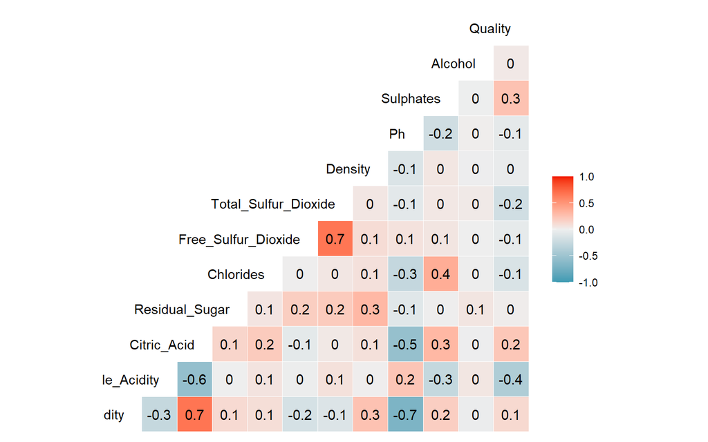

```r
library(GGally)
ggcorr(red_wines_quality, label = T, hjust =1)
```

## Normality

Untuk melakukan pengecekan bahwa residual dari model yang telah kita buat itu berdistribusi normal atau tidak, kita bisa menggunakan uji shapiro test atau bisa juga dengan menggunakan histogram.

Uji hipotesis dalam normality yaitu : H0 : residual berdistribusi normal H1 : residual tidak berdistribusi normal

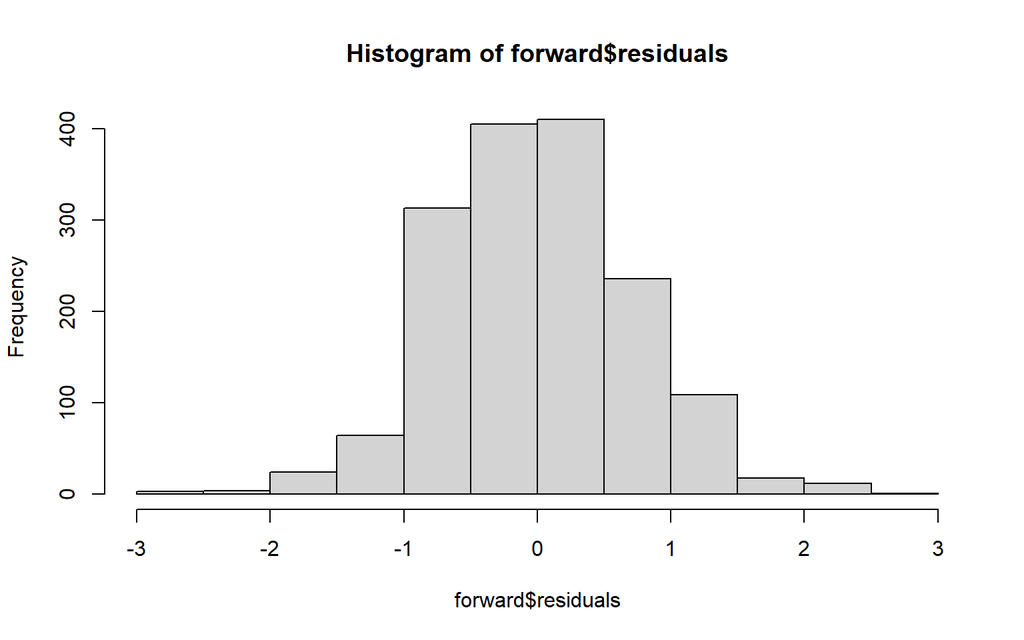

```r
library(MASS)
hist(forward$residuals)
```

```r
shapiro.test(forward$residuals)
```

```
##
##  Shapiro-Wilk normality test
##
## data:  forward$residuals
## W = 0.99314, p-value = 9.1e-07
```

## No Heterskedastisity

Untuk melakukan pengecekan no-heteroskedastisity, kita bisa melihat persebaran dari resisual data kita atau bisa menggunakan Breuche Pagan test.

uji hipotesisnya adalah sebagai berikut :

H0: error tidak memiliki pola H1: errornya berpola

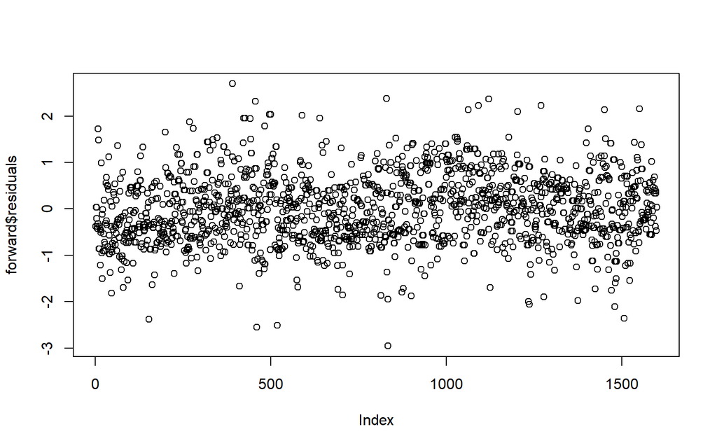

```r
plot(forward$residuals)
```

```r
library(lmtest)
bptest(forward)
```

```
##
##  studentized Breusch-Pagan test
##
## data:  forward
## BP = 44.571, df = 8, p-value = 4.436e-07
```

## No Multikolinearity

Untuk melihat bahwa data yang kita gunakan tidak terdapat multikolinearitas, kita bisa menggunakan nilai VIF, dimana ketika nilai VIF < 10, maka data yang kita gunakan tidak terdapat multikolinearitas.

```r
library(car)
vif(forward)
```

```
##             Alcohol    Volatile_Acidity      Residual_Sugar Free_Sulfur_Dioxide
##            1.005940            1.143293            1.147752            1.093224
##             Density                  Ph           Sulphates       Fixed_Acidity
##            1.192803            1.916773            1.104193            2.108793
```

```r
model_fix <- lm(formula = Quality ~ Alcohol + Volatile_Acidity + Free_Sulfur_Dioxide + Ph + Sulphates + Fixed_Acidity, data = red_wines_quality)
summary(model_fix)
```

```
##
## Call:
## lm(formula = Quality ~ Alcohol + Volatile_Acidity + Free_Sulfur_Dioxide +
##     Ph + Sulphates + Fixed_Acidity, data = red_wines_quality)
##
## Residuals:
##      Min       1Q   Median       3Q      Max
## -2.96042 -0.51792 -0.01723  0.46978  2.67483
##
## Coefficients:
##                       Estimate Std. Error t value Pr(>|t|)
## (Intercept)          3.8385098  0.6394391   6.003 2.40e-09 ***
## Alcohol              0.0012572  0.0005523   2.276  0.02295 *
## Volatile_Acidity    -1.6126631  0.1084559 -14.869  < 2e-16 ***
## Free_Sulfur_Dioxide -0.0046710  0.0017714  -2.637  0.00845 **
## Ph                   0.5767636  0.1628655   3.541  0.00041 ***
## Sulphates            0.8131590  0.1128975   7.203 9.08e-13 ***
## Fixed_Acidity        0.0316412  0.0146453   2.160  0.03088 *
## ---
## Signif. codes:  0 '***' 0.001 '**' 0.01 '*' 0.05 '.' 0.1 ' ' 1
##
## Residual standard error: 0.7284 on 1592 degrees of freedom
##   (1 observation deleted due to missingness)
## Multiple R-squared:  0.1894, Adjusted R-squared:  0.1864
## F-statistic:    62 on 6 and 1592 DF,  p-value: < 2.2e-16
```

```r
vif(model_fix)
```

```
##             Alcohol    Volatile_Acidity Free_Sulfur_Dioxide                  Ph
##            1.002567            1.135752            1.033928            1.903961
##           Sulphates       Fixed_Acidity
##            1.102872            1.958055
```

```r
shapiro.test(model_fix$residual)
```

```
##
##  Shapiro-Wilk normality test
##
## data:  model_fix$residual
## W = 0.99268, p-value = 3.915e-07
```

```r
bptest(model_fix)
```

```
##
##  studentized Breusch-Pagan test
##
## data:  model_fix
## BP = 34.413, df = 6, p-value = 5.598e-06
```

## Conclusion

Berdasarkan dari hasil analisis regresi yang dilakukan, karena setelah di cek asumsi banyak asumsi yang tidak terpenuhi. Terkadang ketika dalam bisnis, asumsi tidak terlalu dihiraukan, namun ada baiknya digunakan pengecekan asumsi.

Arti dari model tersebut adalah ketika bertambah satu satuan untuk nilai alcohol, maka akan menaikkan quality dari red wine. Sedangkan ketika bertambah satu satuan nilai volatile.acidity, maka akan menurunkan tingkat quality dari red wine.

# Referensi

https://rpubs.com/inayatus/linear-regression